# Assignment2

Vienna Saccomanno

2/10/2019

```r
#Attach packages
library(tidyverse)
library(scales)
library(lubridate)
library(boot)
```

## Task 1. Cetaceans in Captivity

```r
#Load data
cetaceans<- read_csv("captive_cetacean.csv")
```

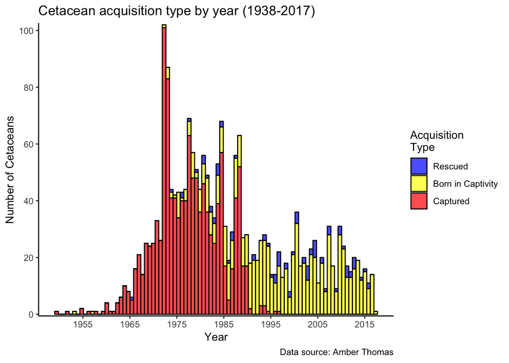

```r
#Wrangle data
cod<- cetaceans %>%
  filter(acquisition %in% c("Rescue", "Capture", "Born")) %>%
  mutate(acquisition = recode_factor(acquisition,
   'Rescue' = 'Rescued', 'Born' = 'Born in Captivity', 'Capture' = 'Captured')
  )

#Plot acquisition over time
cod_viz<- cod %>%
  ggplot(aes(x=originDate, fill=as.factor(acquisition)))+
                   geom_histogram(alpha=0.7, bins = 90, color= "black", linetype = "solid") +
  scale_fill_manual(name= "Acquisition\nType", values = c("Captured" = "red",
                              "Born in Captivity"="yellow",
                              "Rescued" = "blue"))+
  scale_x_date(breaks = date_breaks("10 years"),
               labels = date_format("%Y")) +
  scale_y_discrete(limits=seq(0,170,20))+
  labs(x= 'Year',
       y= 'Number of Cetaceans',
       title = "Cetacean acquisition type by year (1938-2017)",
       caption = "Data source: Amber Thomas")+
  theme_classic()

cod_viz
```

## Task 2. Parameter Estimation - Wild Fish Catch

```r
#Read-in catch data
catch<- read_csv("fish_catch.csv")

#Setting "Year" to a sequence of numbers
catch_seq<- catch %>%
  mutate("seq"= seq(from=0, to=62))
```

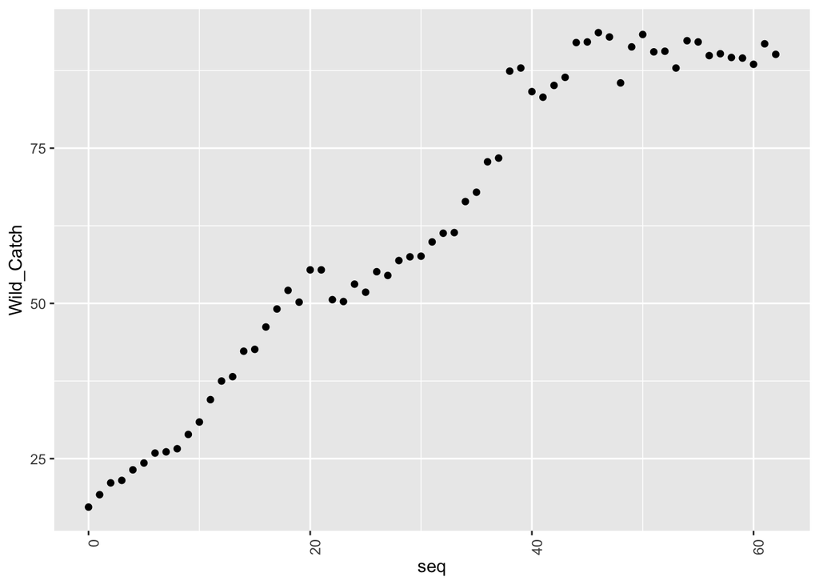

```r
#Making an exploratory graph to estimate the structure of the data
ggplot(catch_seq, aes(x=seq, y=Wild_Catch))+
  geom_point()+
  theme(axis.text.x=element_text(angle=90, hjust=1))
```

```r
#Estimate B
Bestimate<- (90 - 15)/15
```

#### Exploratory graph interpretation

- The wild catch data from 1950-2012 look non-linear and fairly logistic.
- Logistic growth equation:
  $$N_t = \frac{A}{1+Be^{-rt}}$$
- Initial estimates:
- Estimate for K/A: ~ 90 million tons
- Estimate for N0: ~ 15 million tons
- BEstimate:(90 - 15)/15 = 5
- Estimate for r: ~0.05749

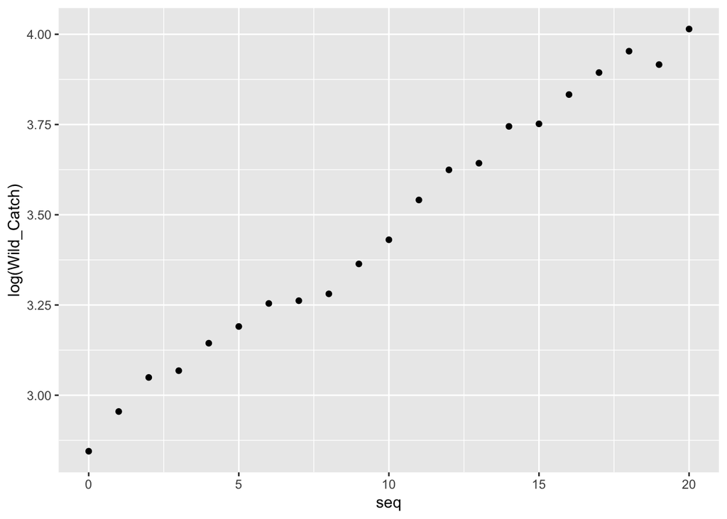

```r
#Looking at the graph, 1950-1970 (i.e. 1-20) was the exponential catch phase. Slope of natural log (y=e^rt -> ln(y) = rt) = r.

#Estimate r (the catch rate). Isolate the first 20 points
r_est <- catch_seq %>%
  filter(seq<21)

#Make sure the log is linear
ggplot(r_est, aes(x=seq, y=log(Wild_Catch)))+
  geom_point()
```

```r
#Estimate r
lm(log(Wild_Catch) ~seq, data=r_est)
```

```
##
## Call:
## lm(formula = log(Wild_Catch) ~ seq, data = r_est)
##
## Coefficients:
## (Intercept)          seq
##     2.88981      0.05749
```

```r
#r initial = 0.05749
```

```r
#Model fitting
catch_fit <- nls(Wild_Catch ~ A/(1+B*exp(-r*seq)),
                start = list(A = 90, B = 5, r = 0.05749),
                data = catch_seq, trace = TRUE)
```

```
## 16537.35 :  90.00000  5.00000  0.05749
## 1822.076 :  92.59571881  3.70845315  0.07388414
## 1394.63 :  100.3449596   4.2130444   0.0677551
## 1365.324 :  100.0501883   4.3201578   0.0702051
## 1365.147 :  100.30626279   4.31450258   0.06983146
## 1365.143 :  100.2735951   4.3165858   0.0698955
## 1365.143 :  100.2791640   4.3162869   0.0698854
## 1365.143 :  100.27828357   4.31633561   0.06988701
```

#### Nonlinear least squares parameter outcome

- Least squares are converging at 1365.1
- A=100.28 million tons
- B=4.32 million tons
- r=0.06989

```r
A <- coef(catch_fit)[1]
B <- coef(catch_fit)[2]
r <- coef(catch_fit)[3]

#Create a new sequence of time values (time_seq)
time_seq <- seq(0,100, length = 100)

#Using the parameters (A, B, and r) and the time sequence, predict the catch for the logistic growth model
catch_pred <- A/(1+B*exp(-r*time_seq))

#Binding together the time sequence data and the predictions data into a new data frame
pred_df <- data.frame(time_seq, catch_pred)
```

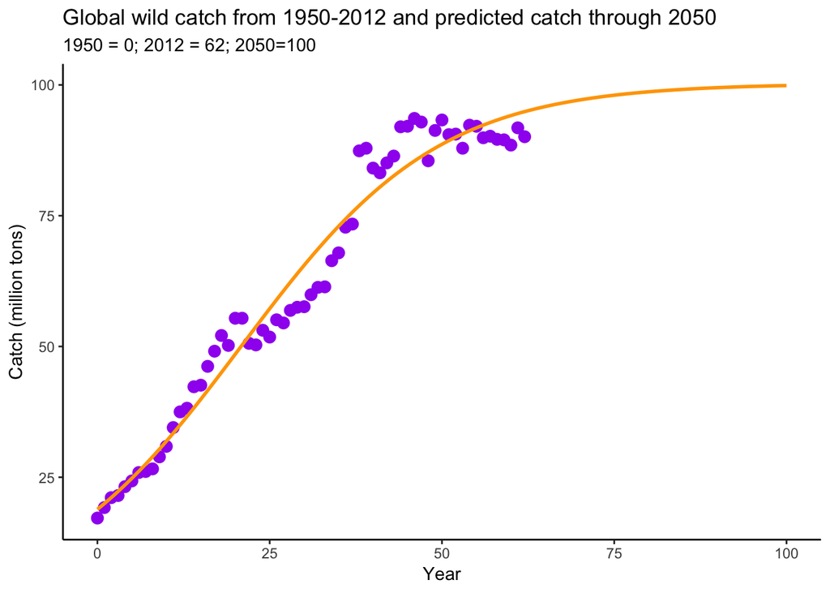

```r
ggplot(catch_seq, aes(x = seq, y = Wild_Catch)) +
  geom_point(colour = "purple", size = 3) +
  theme_bw() +
  geom_line(data = pred_df, aes(x = time_seq, y = catch_pred), colour = "orange", size = 1) +
  labs(x="Year",
       y= "Catch (million tons)",
       title = "Global wild catch from 1950-2012 and predicted catch through 2050",
       subtitle = "1950 = 0; 2012 = 62; 2050=100") +
  theme_classic()
```

```r
#Read in data
survey <- read_csv("boot.csv")
survey_2<- as.vector(survey$member)
```

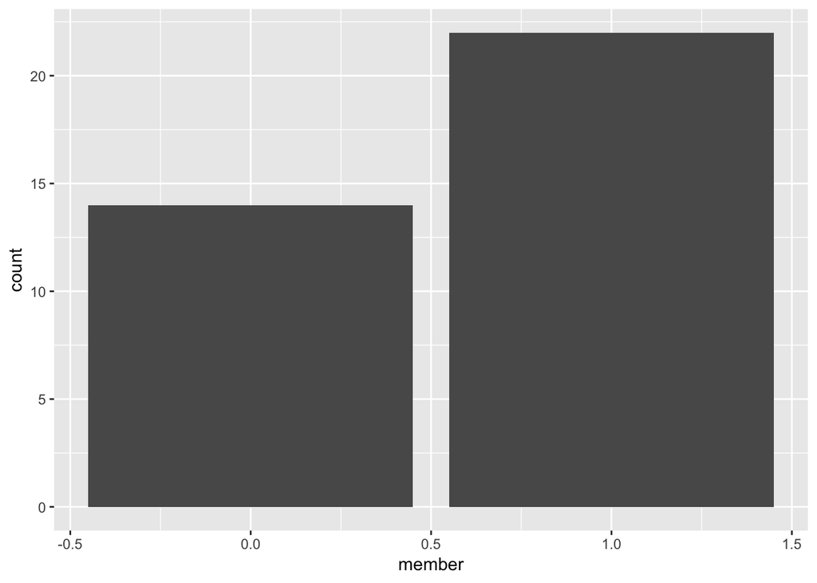

```r
ggplot(survey, aes(member))+
  geom_bar()
```

```r
# Create a function to calculate the proportion of varying vectors (x) of index (i). i = bootstap sample number allowing things to be sequential. x= full sample of 36 people
proportion_fun <- function(x,i){sum(x[i])/length(x[i])}
proportion_fun(survey_2)
```

```
## [1] 0.6111111
```

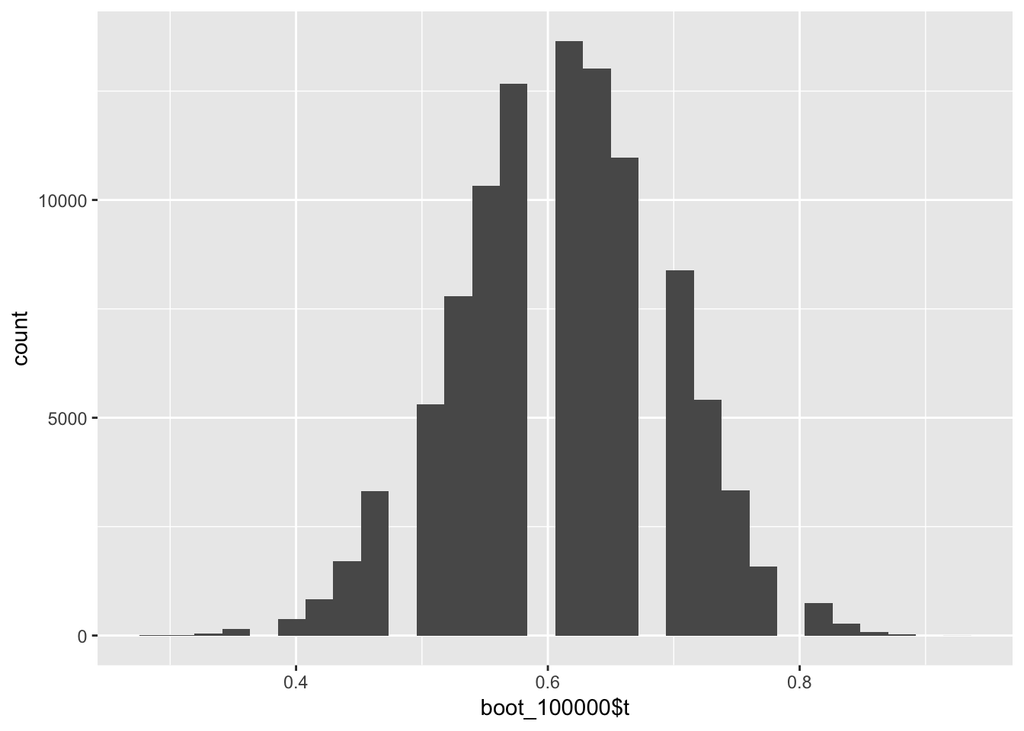

```r
# 100,000 bootstrap samples:
boot_100000 <- boot(survey_2, proportion_fun, R=100000)
#boot_100000$t # to report proportion of all 10 bootstrap samples
#boot_100000$t0 # to report the proportion of the original sample
#boot_100000

ggplot() +
  aes(boot_100000$t) +
  geom_histogram()
```

```r
#boot.ci(boot_100000, conf.=.95)
```

## Task 4. RStudio Conference Talks

#### Talk 1: Shiny in production: principles, practices, and tools - Joe Cheng

2. Interesting things that you learned: -Shinyloadtest is a tool to test app latency, or how long it takes sessions to succeed when multiple users are using the app.When app is slow, use a profiler (profis) to figure out where time is being spent and always try to avoid loading raw data into Shiny and save data frames as “feather” files for faster reading. -Plot caching is a new option that can seep the app up if you have slow plots.
3. One question that you would have liked to asked the speaker -Is it worth it to design more simplistic plots to avoid latency?

#### Talk 2:Spatial data science in the Tidyverse - Edzer Pebesma

2. Interesting things that you learned -Simple features (sf) package can be used to extend tables to spatial tables -Data cubes are array data where values are given for each combination of the dimension values. The “stars” package can help by reading, manipulating, writing and plotting spatiotemporal arrays (including raster data) in R
3. One question that you would have liked to asked the speaker -Can you provide more examples about the different applications of sf and stars?